# Plotting Exercise

Riccardo Fusaroli

May 23, 2016

The exercise explores questions on fuel economy of cars produced in different regions.

The data is a real dataset from the EPA, which is available within R through the package fueleconomy.

We will now load the relevant packages: - fueleconomy contains the data - dplyr contains functions to easily subset and manipulate your data - ggplot2 allows you to visualize the data in fancy ways

```r
library(dplyr)
```

```r
library(fueleconomy)
library(ggplot2)
```

### Subsetting

Sometimes you need to only look at a subset of your data. Here we learn how to select subsets of a dataset: a subset of car makes: “Chevrolet”,“Dodge”,“Ford”,“Mitsubishi”,“Nissan”,“Toyota”,“Volvo”,“Volkswagen”,“BMW”

```r
# select specific makes to simplify data set
dat = subset(vehicles,make==c("Chevrolet","Dodge","Ford","Mitsubishi","Nissan","Toyota",
                              "Volvo","Volkswagen","BMW"))
```

### Scatterplot

Let’s visualize the data! We plot the cty (outcome - fuel economy for city driving) against the year of production and attribute different colors to the different makes.

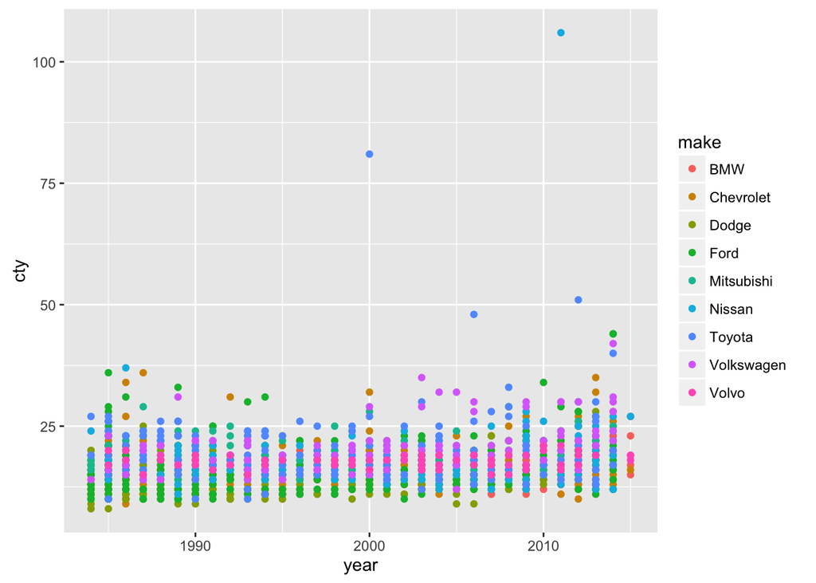

```r
ggplot(dat, aes(year,cty,color=make)) +
  geom_point()
```

### Excluding Data

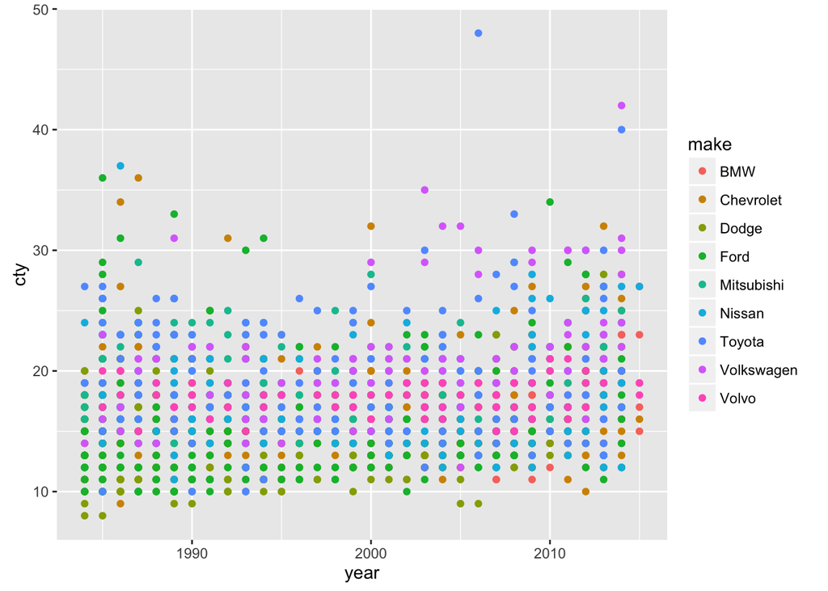

```r
# Exclude electric cars because they are outliers. Discussion on role of outliers and
# a prior vs a posteriori justifications for excluding them
Electric = dat$fuel=="Premium Gas or Electricity" |
  dat$fuel=="Regular Gas or Electricity" |
  dat$fuel=="Electricity"|
  dat$fuel=="Regular Gas and Electricity" |
  dat$fuel=="Premium Gas and Electricity"

dat=dat[!Electric,]

ggplot(dat, aes(year,cty,color=make)) +
  geom_point()
```

### Avoiding Overplotting

Can you spot the difference?

Here is yet another issue: Many cars produced in the same year have the same output, so we can only see one of them (the others are hidden below it). Let’s shake them out of hiding!

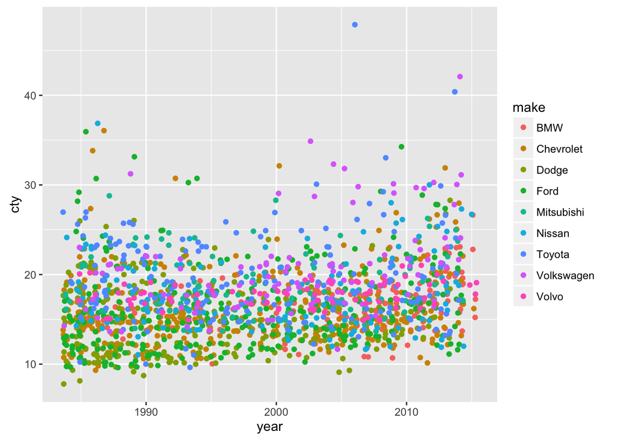

```r
ggplot(dat, aes(year,cty,color=make)) +
  geom_point(position = "jitter")
```

### Recoding Variables

Still it’s kinda hard spotting all those makes. Should we use a rougher classification in geographical areas?

```r
dat$region[dat$make=="Chevrolet"|dat$make=="Dodge"|dat$make=="Ford"]="US"
dat$region[dat$make=="Mitsubishi"|dat$make=="Nissan"|dat$make=="Toyota"]="Asia"
dat$region[dat$make=="Volkswagen"|dat$make=="Volvo"|dat$make=="BMW"]="EU"
```

### Exploring relations

Is there a relation between year and cty? How much does the area of production affects that?

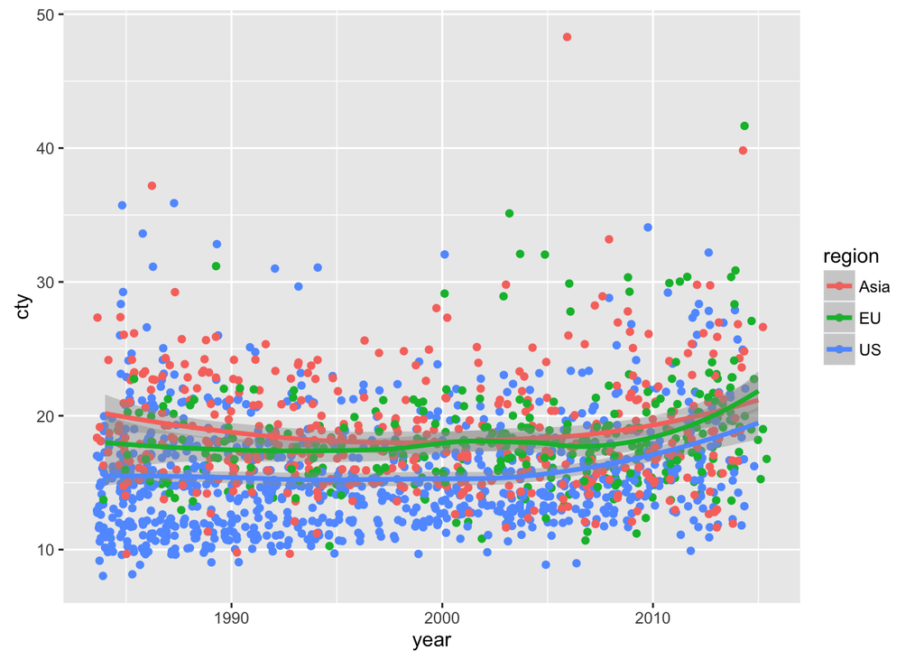

```r
#Loess
ggplot(dat, aes(year,cty,color=region)) +
  geom_point(position = "jitter") +
  stat_smooth(size=1.2)
```

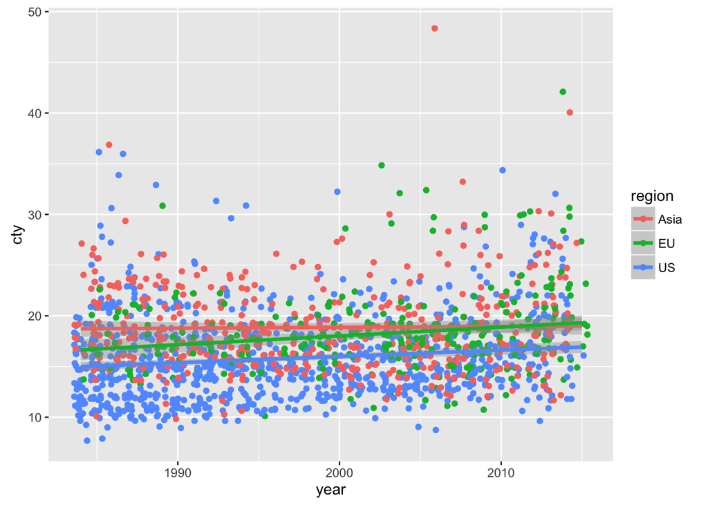

```r
#linear
ggplot(dat, aes(year,cty,color=region)) +
  geom_point(position = "jitter") +
  stat_smooth(method = "lm",size=1.2)
```

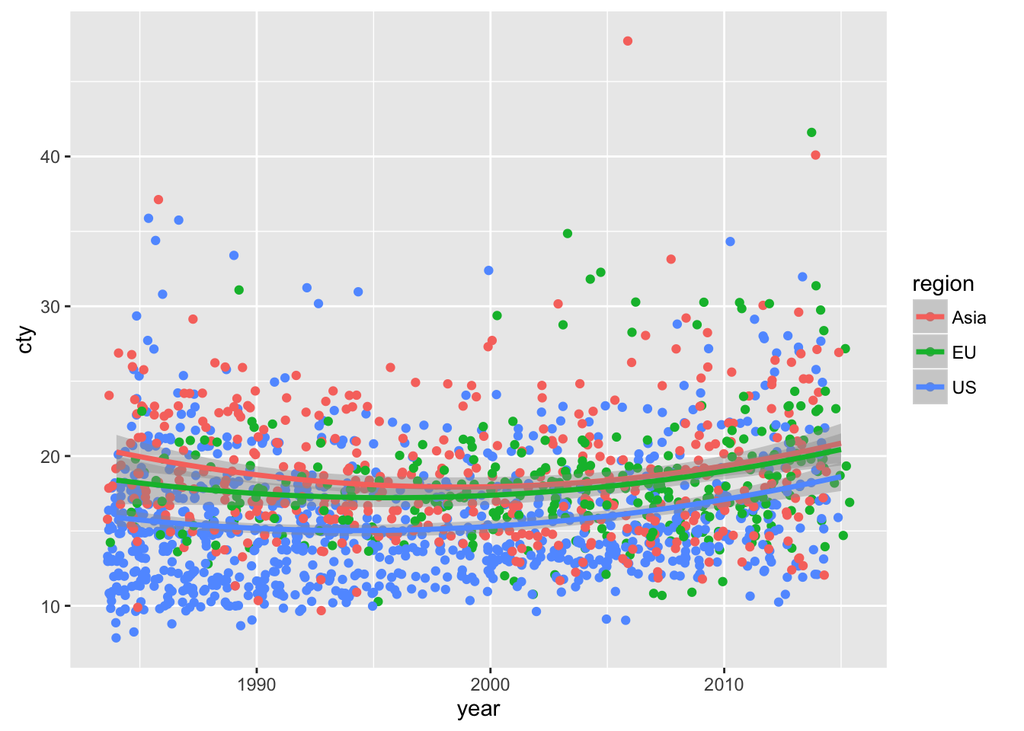

```r
#polynomial
ggplot(dat, aes(year,cty,color=region)) +
  geom_point(position = "jitter") +
  stat_smooth(method = "lm", formula = y ~ poly(x, 2),size=1.2)
```

### Aggregating Data

```r
#produce single variable table
#aggregating data to view at a glance, and set up intuitions about bar-plots
#introduce tilde in R
meanRegion=aggregate(cty~region,data=dat,FUN=mean)
print(meanRegion)
```

```
##   region      cty
## 1   Asia 18.85246
## 2     EU 18.27381
## 3     US 15.76545
```

```r
sdRegion=aggregate(cty~region,data=dat,FUN=sd)
print(sdRegion)
```

```
##   region      cty
## 1   Asia 4.416068
## 2     EU 3.965075
## 3     US 4.181353
```

```r
#produce multi-variable table
#introduce concept of explaining variability by highlighting how the SD decreases when you
#also aggregate according to number of cylinders
meanRegionCyl=aggregate(cty~region*cyl,data=dat,FUN=mean)
sdRegionCyl=aggregate(cty~region*cyl,data=dat,FUN=sd)

print(meanRegionCyl)
```

```
##    region cyl      cty
## 1      US   3 33.25000
## 2    Asia   4 21.22857
## 3      EU   4 21.58095
## 4      US   4 20.99571
## 5      EU   5 18.03846
## 6      US   5 15.50000
## 7    Asia   6 15.97546
## 8      EU   6 17.24242
## 9      US   6 15.30056
## 10   Asia   8 12.89474
## 11     EU   8 14.37500
## 12     US   8 12.64103
## 13     EU  10 12.00000
## 14     US  10 10.80000
## 15     EU  12 12.33333
```

```r
print(sdRegionCyl)
```

```
##    region cyl       cty
## 1      US   3 2.2173558
## 2    Asia   4 4.1336286
## 3      EU   4 4.8014039
## 4      US   4 3.5165837
## 5      EU   5 2.0860088
## 6      US   5 0.8366600
## 7    Asia   6 2.1080414
## 8      EU   6 1.7303806
## 9      US   6 1.8051881
## 10   Asia   8 0.8093026
## 11     EU   8 1.3528223
## 12     US   8 1.9962602
## 13     EU  10 2.0000000
## 14     US  10 2.0493902
## 15     EU  12 2.0816660
```

### Barplots

Let’s now explore these aggregated data with a plot

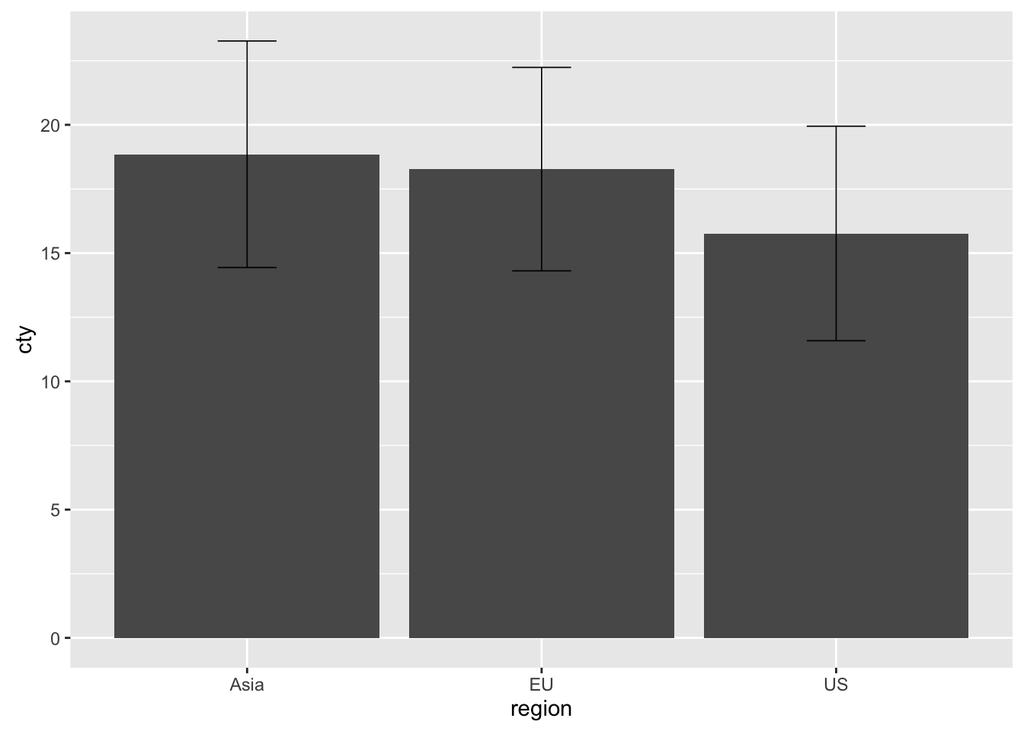

```r
# use aggregated data to plot - simple barplot
ggplot(meanRegion, aes(x=region, y = cty)) +
  geom_bar(stat = 'identity') +
  geom_errorbar(aes(ymin=meanRegion$cty-sdRegion$cty, ymax=meanRegion$cty+sdRegion$cty),
                position=position_dodge(.9),
                stat = 'identity',
                size=.3,    # Thinner lines
                width=.2
  )
```

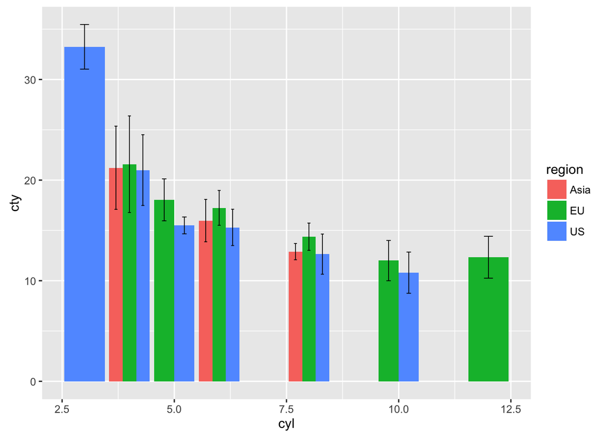

```r
#grouped barplot - emnphasise change in size of error bars
ggplot(meanRegionCyl, aes(x=cyl, y = cty, fill=region)) +
  geom_bar(position="dodge", stat = 'identity') +
  geom_errorbar(aes(ymin=meanRegionCyl$cty-sdRegionCyl$cty, ymax=meanRegionCyl$cty+sdRegionCyl$cty),
                position=position_dodge(.9), stat = 'identity',
                size=.3,    # Thinner lines
                width=.2)
```

### Boxplots and violinplots

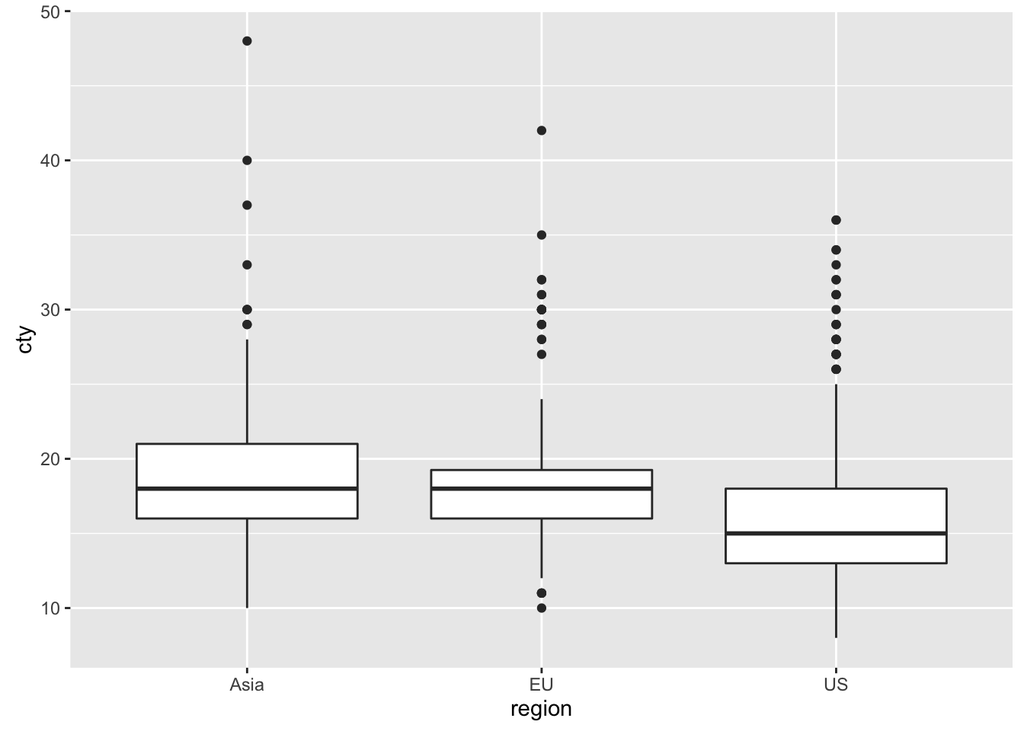

```r
ggplot(dat, aes(x=region, y = cty)) + geom_boxplot()
```

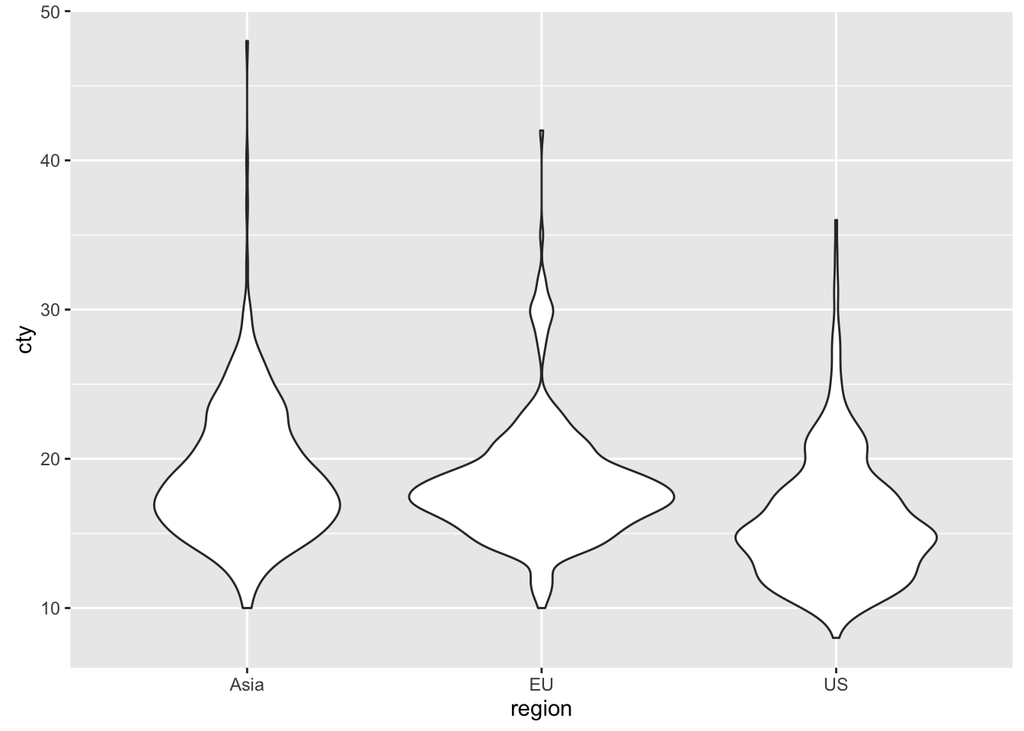

```r
ggplot(dat, aes(x=region, y = cty)) + geom_violin()
```

Round-up discussion: Tuesday - inferences about barplots, Wednesday - inferences about correlation